# Machine Learning

Predictive Models and Classification

## Overview

This page presents machine learning models addressing 3 ML business questions through classification, regression, or clustering.

## Political Clustering

### Business Question 1:

**Question:** How do political discussions in urban subreddits differ in sentiment, style, and content across cities?

### Problem Formulation

- **Task Type:** Unsupervised Clustering
- **Target Variable:** Uncovering what distinct modes of political communication emerge in urban Reddit communities and how these patterns may vary across cities.
- **Evaluation Approach:** Elbow method, qualitative cluster interpretation

### Feature Engineering

**Features Used:**

- Text Embeddings (50 dimensions): TF-IDF features capturing word content and topic information
- Sentiment Features (4 dimensions):
  - Overall sentiment (compound, positive, negative, neutral scores via VADER)
- Linguistic Style Features (7 dimensions):
  - Caps ratio (emphasis/shouting)
  - Exclamation count (emotional intensity)
  - Question count (inquiry patterns)
  - Certainty score (confident language)
  - Hedge score (tentative language)
  - Moral foundations (care/harm, authority/tradition)

### Model Performance

**Results:**

- Optimal k: 8 clusters (determined via elbow method)
- PCA Variance Explained: 58% in 2 components (PC1: 55.1%, PC2: 2.9%)

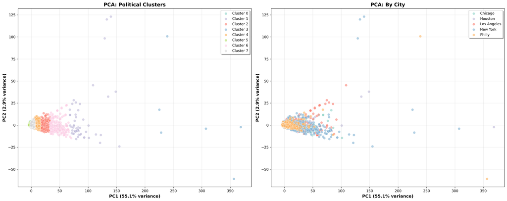

Fig 18. PCA Visualization by Cluster

**Key Insights:**

- The above PCA visualization explains 58% variance in 2D
- Shows high cluster overlap indicating cities don’t naturally seperate by cluster
- Reveals political conversations transcend geography across the United States
- Upon further analysis into outliers, we find that the posts are much longer and list informative content (e.g., links, data, statistics) rather than emotional or stylistic language

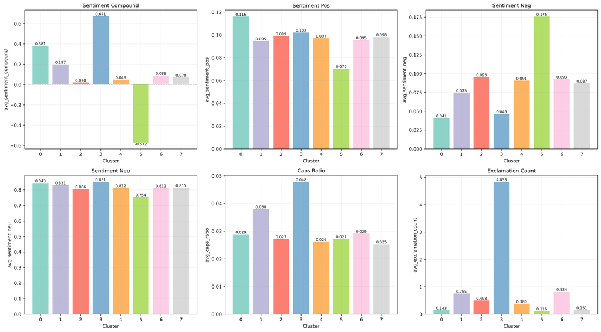

**Key Insights:**

- 8 distinct communication styles identified
- Clear sentiment spectrum: Cluster 5 (negative/complaints) to Cluster 3 (positive/excited)
- Stylistic differences: Cluster 3 uses almost 5 times as more exclaimations and 2 times more caps than others

### Feature Importance

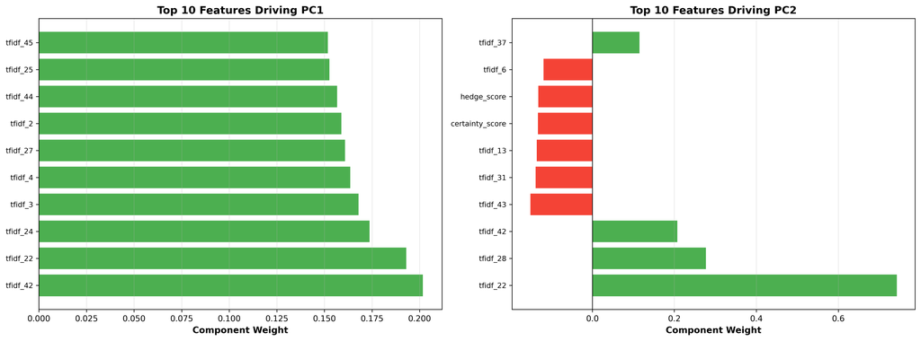

## Food Analysis

### Business Question 2:

**Question:** Can we predict which food-related posts will receive high engagement based on cuisine type, city, and content features?

### Problem Formulation

- **Task Type:** Supervised Learning
- **Target Variable:** Score (Upvotes - Downvotes)
- **Evaluation Approach:** RMSE, R^2, MAE

### Feature Engineering

**Features Used:**

- Text Embeddings (1000 dimensions): TF-IDF features capturing word content and topic information
- Post Features (5 dimensions):
  - Post length
  - Hour posted
  - Day of week
  - If post was on weekend
  - If post had a question

### Model Performance

**Table 3. Model Results**

| rmse | r2 | mae | train_size | test_size |
| --- | --- | --- | --- | --- |
| 29.011887641990654 | 0.106303862268178 | 8.506035699315943 | 555135 | 139240 |

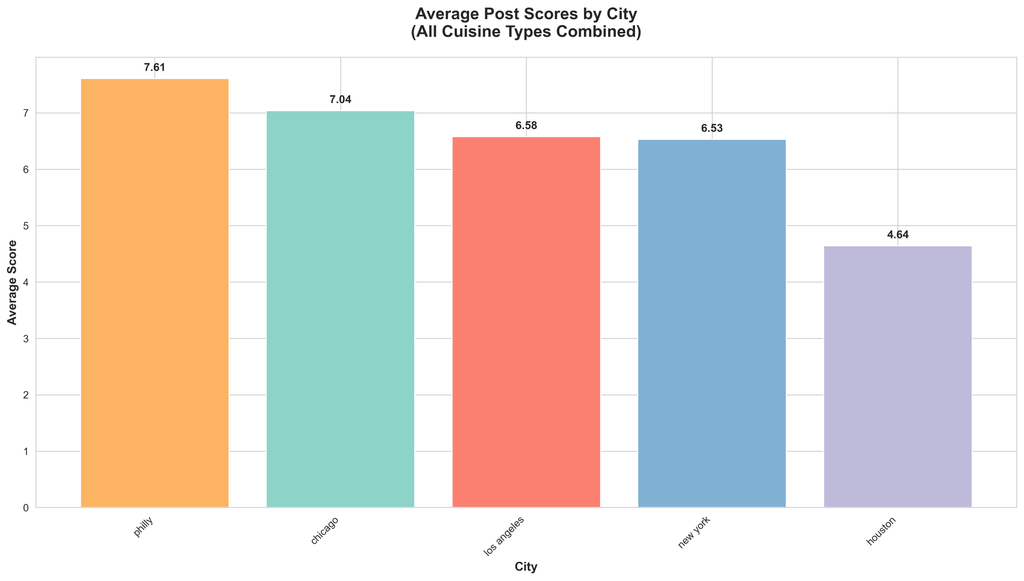

Fig 21. Food Score By City

**Key Insights:**

This graph shows the average score of all food posts in the city. All of the cities have positive scores on average, with Philly having the highest. Houston tends to have the lowest scores and New York and LA are pretty comparable.

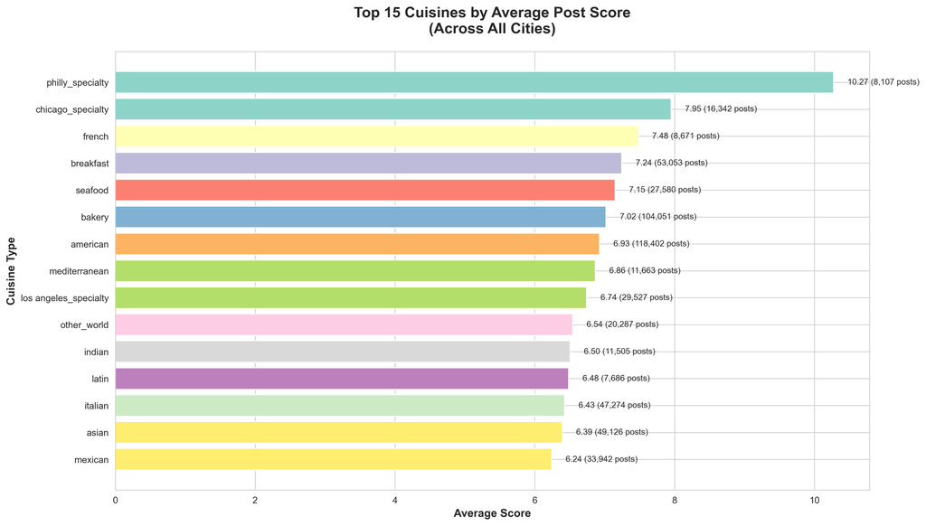

Fig 22. Popular cuisines overall

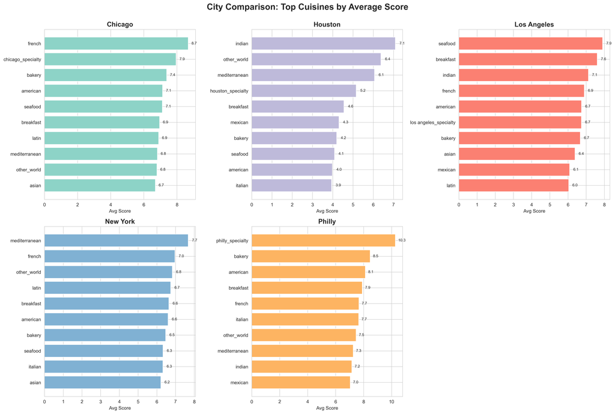

Fig 23. Popular cuisines by city

**Key Insights:**

After categorizing the food posts into specific cuisines based on key word searches, their average scores were calculated by city and displayed on this bar chart. The top cuisines across the cities are drastically different.

Low-Performing Categories:

- Asian cuisine consistently performs poorly relative to other categories across Chicago (6.7), New York (6.2), and Houston (3.78), which is surprising given the prominence of Asian food cultures in these cities

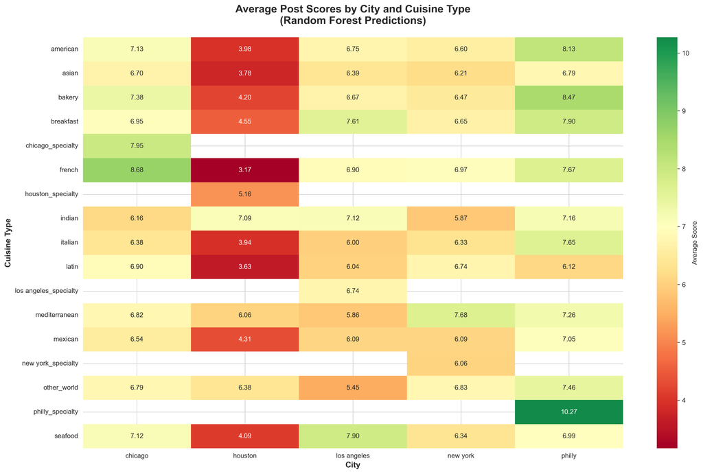

Fig 24. Post scores by city

**Key Insights:**

This heatmap displays the average scores as predicted by the random forest model created for this section. It seems to capture some of the city’s favorites pretty well.

### Feature Importance

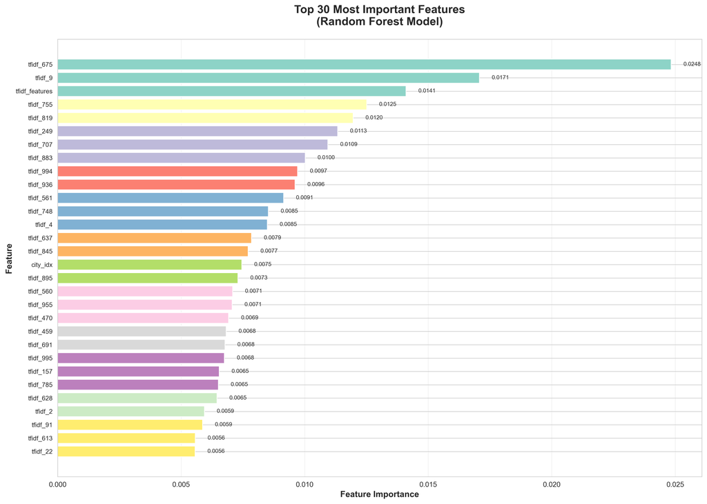

Fig 25. Feature Importance (tfidif)

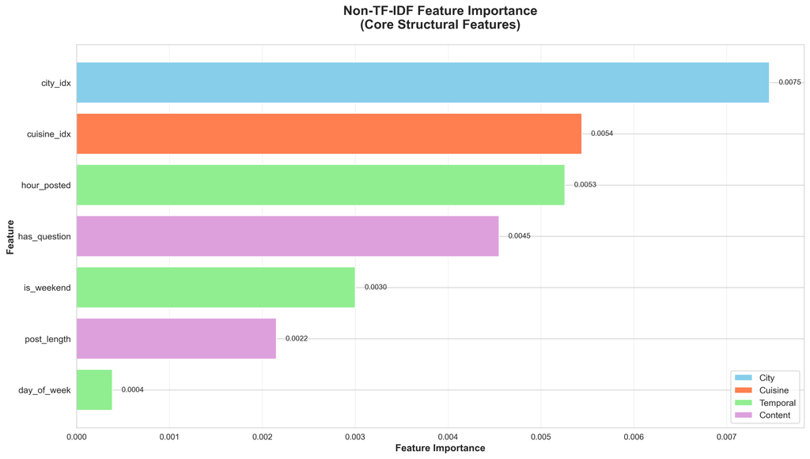

Fig 26. Feature Importance (non-tfidif)

**Key Insights:**

These are the feature importances from the random forest model. The top features are all tf-idf features, meaning that the words used in the posts themselves were the most important when it came to predicting the score.

We filtered out these tf-idf features to see what other important features there were. The top after the text is the city, meaning that there is significant enough variance between the different cities for it to be a differentiator in the random forest.

### Prediction Error

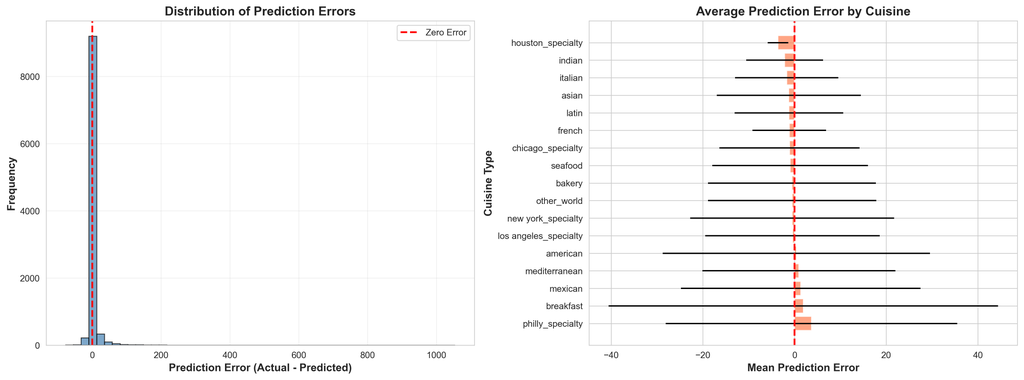

Fig 27. Prediction Error Analysis

**Key Insights:**

Model Performance Overview: - The left panel shows a heavily concentrated error distribution centered near zero, indicating the Random Forest model generally does well weith the dataset

## Text Generation

### Business Question 3:

**Question:** Can we create an average posting for city using a character-based LSTM?

### Problem Formulation

- **Task Type:** Generation
- **Target Variable**: Minimized Loss, Readability
- **Evaluation Metric:** Train vs Validation Loss, Perplexity

### Technical Approach

- Normalize the reddit data (remove punctuations, special characters, convert to lowercase, remove whitespace)
- Filter the subreddits and group by each city
- For each city:
  - Define the training, validation, and test splits of the data using DataLoader
  - Define the **LSTM model**
  - Write a training loop that uses the RNN model
  - Write an evaluation function to hyperparamter tune the model
  - Write a text generation function using the trained and tuned RNN model
  - Prompt the model to **write an average posting**
- The features of this model were all the unique individual characters from the subset of postings
  - The **character level vocabularly** was built
  - Unique characters were extracted (69)
  - Each character was mapped to an index number
  - The full text was encoded with the index mapping
- Thus the encoded text was used to train the LSTM to **predict the next character**
  - The input was a particular sequence of characters, while the target was the same sequence plus the next character (windowed)

### Model Performance

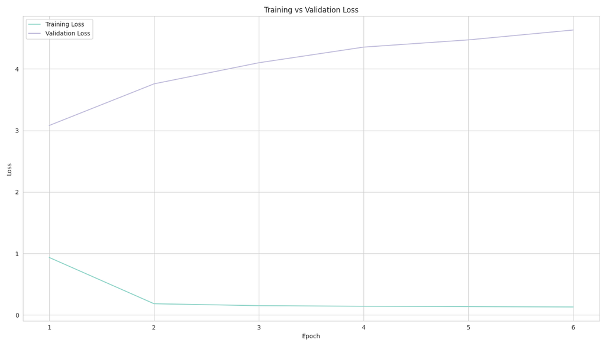

Fig 28. Training vs Validation Loss

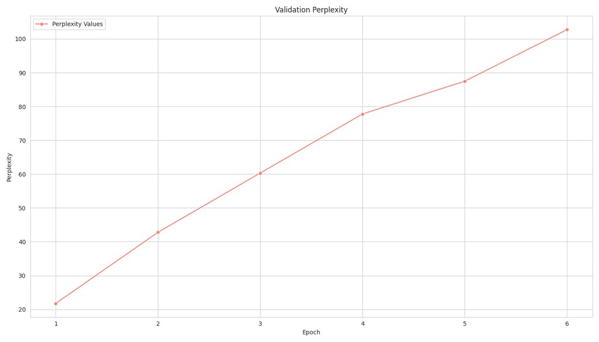

Fig 29. Model Perplexity

### Generated Text

**NoteNew York**

- i tried scanning my **ballpark app ticket** and no credit towards payment occurred when checking out at the concession kiosk
- my pick would be freddie freeman replacing **carlos rodon**.
- the groom to be is a pats fan (fuckin loser)

**TipChicago**

- looking for genuine feedback on buying in the st. bernard pocket neighborhood in **englewood**
- i’m primarily nervous about the ability to sign a lease without proof ofincome, i do have cosigners but can’t speak for my roommates. i have rises or reserved a parking space at **o’hare** from this

**CautionPhilly**

- looking for a roommate for a bed/2bath apartment in **chinatown a few blocks from reading terminal**.
- there is so much skill and talent within philadelphia, the birthplace of **graffiti**

**ImportantLos Angeles**

- but i’m wondering if **lax might be more strict** with issuing these passes? she is in her 80’s and can walk ok, but we usually arrange wheelchair
- any advice on how you got into **usc**
- ive been a ballerina/contemporary **dancer**, got my degree in dance and got gigs for burlesque

**NoteHouston**

- in houston but having trouble finding something awesome that is open **post-beryl** taking a dump on your city. i had planned to eat at **chopnblock** but they look out of commission. does anyone knows whats going on there/eta on being back? ps. **im from new orleans, so no cajun/creole**, please. otherwise, good food is

### Key Insights:

Limitiations aside, the short snippets of the posts are quite **city specific** and reveal an interesting diversity of conversations across the subreddits. What we mainly see is that the model was able to learn interesting aspects about each city, we see specific neighborhoods, landmarks, airports, restaurants, sports references, etc.

- For **Chicago** we see O’hare airport and the Englewood neighborhood.
- For **Houston**, Hurricane Beryl, which hit Texas in 2024, is mentioned.
- For **LA** we see LAX, USC, and mention of the arts.
- For **NYC**, there is lots of baseball and Yankees talk and even some vulgarity directed at Patriots fans.
- For **Philly**, Chinatown and the Reading Terminal are mentioned, which is particularly interesting that the model understood there geographic connection.

Overall, we are seeing that there is **diversity in postings across the cities, and it is reflected in the ML created posts**.

### Limitations:

The main limitation was computing power. For an LSTM of any generative model to train on around 2 million characters, would need the power of a GPU. However, for this project, the CPU was used and some limitations were places on the model.

“(00:00:19)](https://bdata-producedclips.mlb.com/5acad5d6-0d09-4c4f-88ff-a890cdb301a2.mp4)| ||1|2|3|4|5|6|7|8|9||r|h|e|lob| |:–|:–|:–|:–|:–”

## Summary

### Answers to ML Business Questions

1. **How do political discussions in urban subreddits differ in sentiment, style, and content across cities?**: Our analysis uncovered eight distinct political communication modes in urban subreddits, spanning from enthusiastic mobilization (Cluster 3: high positive sentiment + exclamations) to critical complaints (Cluster 5: high negative sentiment). The absence of geographic clustering suggests political discourse follows national rather than local narratives.
2. **Can we predict which food-related posts will receive high engagement based on cuisine type, city, and content features?**: While the model is not very strong in R^2, it performs well on the typical food related posts with scores in normal ranges and gives insight into the vastly different engagement cities have with different cuisine types (and how much of a preference they have for their own specialty foods)
3. **Can we create an average posting for each city using a character-based LSTM?**: While the model still faces some limitiations, namely in computing power, it was able to produce short snippets of coherent text that could reasonably be found within a Subreddit and are city specific. The model was able to identify common references and landmarks within each city and generate text surronding these references that mimick an average posting.

### Business Implications

- Reddit posts and overall political advertising can be better targeted to susceptible individuals based on their political clustering and the rhetoric and sentiment they tend to utilize on Reddit.
- Optimize restaurant advertising by posting specifically about foods that are a city speciality to generate high engagement and draw interested customers on Reddit.
- The LSTM could be leveraged to maximize post engagement by creating template postings and identify important language and references that garner acceptance within a city subreddit.

**Tip**

All ML code is in `code/ml/` directory. Models saved in `code/ml/models/`.